# Distributive Fairness Appeals: Equality, Reciprocity, or Need

Materials, data, code accompanying the article “Equality, Reciprocity, or Need? Bolstering Welfare Policy Support for Marginalized Groups with Distributive Fairness”.

# Study 1

## Data

### Data load

```r
s1 <- import("data/Study1.sav")
```

### Data prep

```r
s1 <- dplyr::filter(s1, complete.cases(E1A | E1B | E2A | E2B))

s1$SEX <- factor(s1$SEX, levels = c(1, 2), labels = c("Male","Female"))
s1$AGECAT= factor(s1$AGECAT, levels = c(1, 2,3,4,5,6), labels = c("18-24","25-34","35-44", "45-54","55-64","65+"))
s1$EDU= factor(s1$EDU, levels = c(1, 2,3,4), labels = c("Primary","Secondary (no diploma)","Secondary (complete)", "University"))
s1$SIZE= factor(s1$SIZE, levels = c(1, 2,3,4,5), labels = c("less than 1k","1k-4 999","5k-19 999", "20k - 99 999","100k+"))
s1$REG= factor(s1$REG, levels = c(1, 2,3,4,5,6,7,8), labels = c("Bratislavsky","Trnavsky","Trenciansky", "Nitriansky","Zilinsky","Banskobystricky","Presovsky","Kosicky"))

s1$PINCOME <- as.factor(s1$PINCOME)

income <- dplyr::filter(s1, PINCOME != '8' & PINCOME != '9')
income$PINCOME <- as.ordered(income$PINCOME)
median(income$PINCOME)
```

```
## [1] "2"
```

```r
s1$income <- car::recode(s1$PINCOME,"'1'='below median';'2'='below median'; '8'='NA';'9'='NA'; else = 'above median'")


s1$condition1 <- s1$E1A
s1$condition2 <- s1$E1B
s1$condition3 <- s1$E2A
s1$condition4 <- s1$E2B

s1$condition1[!is.na(s1$condition1)] <- "E1A"
s1$condition2[!is.na(s1$condition2)] <- "E1B"
s1$condition3[!is.na(s1$condition3)] <- "E2A"
s1$condition4[!is.na(s1$condition4)] <- "E2B"

s1$condition <- paste(s1$condition1,s1$condition2,s1$condition3,s1$condition4)
cols <- c("condition1","condition2","condition3","condition4")
s1$condition <- apply(s1[, cols], 1, function(x) toString(na.omit(x)))
s1$condition= factor(s1$condition,  labels = c('S1:Non-Roma settlement', 'S1:Roma settlement','S2:Not including Roma','S2:Including Roma'))

s1$outcome <- paste_na(s1$E1A,s1$E1B,s1$E2A,s1$E2B)
s1$outcome <- as.numeric(s1$outcome)

s1_1 <- dplyr::filter(s1, E1A > 0 | E1B > 0)
s1_1 <- s1_1[, -c(13:14)]
s1_1$group <- s1_1$E1A
s1_1$group[is.na(s1_1$group)] <- "B"
s1_1$group <- car::recode(s1_1$group,"'B'='Roma settlement'; else='Non-Roma settlement'")
s1_1$group <- as.factor(s1_1$group)
s1_1$well <- with(s1_1, pmax(E1A, E1B, na.rm = TRUE))
s1_1$group <- relevel(s1_1$group, "Roma settlement")

s1_2 <- dplyr::filter(s1, E2A > 0 | E2B > 0)
s1_2 <- s1_2[, -c(11:12)]
s1_2$group <- s1_2$E2A
s1_2$group[is.na(s1_2$group)] <- "B"
s1_2$group <- car::recode(s1_2$group,"'B'='including Roma'; else='not including Roma'")
s1_2$policies <- with(s1_2, pmax(E2A, E2B, na.rm = TRUE))
s1_2$group <- as.factor(s1_2$group)
s1_2$group <- relevel(s1_2$group, "including Roma")

#na <- dplyr::filter(s1, !complete.cases(E1A | E1B | E2A | E2B))
```

## Descriptives

### Main outcome

```r
s1_1 %>% dplyr::group_by(group) %>% dplyr::summarise(N = length(well), Min=min(well,na.rm= TRUE),Q1 = quantile(well,probs = .25,na.rm = TRUE),Median = median(well, na.rm = TRUE),Q3 = quantile(well,probs = .75,na.rm = TRUE),Max = max(well,na.rm = TRUE),Mean = mean(well, na.rm = TRUE),SD = sd(well, na.rm = TRUE), Skew = skewness(well, na.rm = TRUE), Kurtosis = kurtosis(well, na.rm = TRUE)) -> s11_table

knitr::kable(s11_table, caption = "Study 1 - 1")%>%
  kable_styling(full_width = F)
```

Study 1 - 1

| group | N | Min | Q1 | Median | Q3 | Max | Mean | SD | Skew | Kurtosis |
| --- | --- | --- | --- | --- | --- | --- | --- | --- | --- | --- |
| Roma settlement | 251 | 1 | 2 | 6 | 8 | 11 | 5.68 | 3.51 | 0.175 | -1.250 |
| Non-Roma settlement | 252 | 1 | 6 | 9 | 11 | 11 | 8.38 | 2.81 | -0.829 | -0.265 |

```r
s1_2 %>% dplyr::group_by(group) %>% dplyr::summarise(N = length(policies), Min=min(policies,na.rm= TRUE),Q1 = quantile(policies,probs = .25,na.rm = TRUE),Median = median(policies, na.rm = TRUE),Q3 = quantile(policies,probs = .75,na.rm = TRUE),Max = max(policies,na.rm = TRUE),Mean = mean(policies, na.rm = TRUE),SD = sd(policies, na.rm = TRUE), Skew = skewness(policies, na.rm = TRUE), Kurtosis = kurtosis(policies, na.rm = TRUE)) -> s12_table

knitr::kable(s12_table, caption = "Study 1 - 2")%>%
  kable_styling(full_width = F)
```

Study 1 - 2

| group | N | Min | Q1 | Median | Q3 | Max | Mean | SD | Skew | Kurtosis |
| --- | --- | --- | --- | --- | --- | --- | --- | --- | --- | --- |
| including Roma | 253 | 1 | 2 | 6 | 9 | 11 | 5.72 | 3.76 | 0.186 | -1.432 |
| not including Roma | 246 | 1 | 7 | 9 | 11 | 11 | 8.75 | 2.52 | -0.972 | 0.226 |

### Sample characteristics

```r
s1_gender <- s1 %>% group_by(SEX) %>%
dplyr::summarise(n = n()) %>%
  mutate(freq = n / sum(n))
s1_gender$freq <- round(s1_gender$freq, 3)

s1_gender%>%
kable(caption = "Gender")%>%
  kable_styling(full_width = F)
```

Gender

| SEX | n | freq |
| --- | --- | --- |
| Male | 477 | 0.476 |
| Female | 525 | 0.524 |

```r
s1_age <- s1 %>% dplyr::summarise(Min=min(AGE,na.rm= TRUE),Q1 = quantile(AGE,probs = .25,na.rm = TRUE),Median = median(AGE, na.rm = TRUE),Q3 = quantile(AGE,probs = .75,na.rm = TRUE),Max = max(AGE,na.rm = TRUE),Mean = round(mean(AGE, na.rm = TRUE),3),SD = round(sd(AGE, na.rm = TRUE),2),n = n(),Missing = sum(is.na(AGE)))

s1_age %>%
  kable(caption = "Age") %>%
  kable_styling(full_width = F)
```

Age

| Min | Q1 | Median | Q3 | Max | Mean | SD | n | Missing |
| --- | --- | --- | --- | --- | --- | --- | --- | --- |
| 18 | 30 | 43 | 57 | 87 | 43.6 | 15.9 | 1002 | 0 |

```r
s1_agecat  <- s1 %>% group_by(AGECAT) %>%
dplyr::summarise(n = n()) %>%
  mutate(freq = n / sum(n))
s1_agecat$freq <- round(s1_agecat$freq, 3)

s1_agecat%>%
kable(caption = "Age categories")%>%
  kable_styling(full_width = F)
```

Age categories

| AGECAT | n | freq |
| --- | --- | --- |
| 18-24 | 131 | 0.131 |
| 25-34 | 212 | 0.212 |
| 35-44 | 188 | 0.188 |
| 45-54 | 185 | 0.185 |
| 55-64 | 159 | 0.159 |
| 65+ | 127 | 0.127 |

```r
s1_educat <- s1 %>% group_by(EDU) %>%
dplyr::summarise(n = n()) %>%
  mutate(freq = n / sum(n))
s1_educat$freq <- round(s1_educat$freq, 3)

s1_educat%>%
kable(caption = "Education categories")%>%
  kable_styling(full_width = F)
```

Education categories

| EDU | n | freq |
| --- | --- | --- |
| Primary | 97 | 0.097 |
| Secondary (no diploma) | 348 | 0.347 |
| Secondary (complete) | 379 | 0.378 |
| University | 178 | 0.178 |

```r
s1_reg <- s1 %>% group_by(REG) %>%
dplyr::summarise(n = n()) %>%
  mutate(freq = n / sum(n))
s1_reg$freq <- round(s1_reg$freq, 3)

s1_reg%>%
kable(caption = "Region")%>%
  kable_styling(full_width = F)
```

Region

| REG | n | freq |
| --- | --- | --- |
| Bratislavsky | 121 | 0.121 |
| Trnavsky | 116 | 0.116 |
| Trenciansky | 114 | 0.114 |
| Nitriansky | 125 | 0.125 |
| Zilinsky | 123 | 0.123 |
| Banskobystricky | 113 | 0.113 |
| Presovsky | 141 | 0.141 |
| Kosicky | 149 | 0.149 |

```r
s1_municip <- s1 %>% group_by(SIZE) %>%
dplyr::summarise(n = n()) %>%
  mutate(freq = n / sum(n))
s1_municip$freq <- round(s1_municip$freq, 3)

s1_municip%>%
kable(caption = "Municipality size")%>%
  kable_styling(full_width = F)
```

Municipality size

| SIZE | n | freq |
| --- | --- | --- |
| less than 1k | 133 | 0.133 |
| 1k-4 999 | 288 | 0.287 |
| 5k-19 999 | 159 | 0.159 |
| 20k - 99 999 | 278 | 0.277 |
| 100k+ | 144 | 0.144 |

### Randomization checks

```r
s1_check <- dplyr::select(s1, SEX:PINCOME, -AGECAT, condition)
s1_check <- mutate_all(s1_check, function(x) as.numeric(x))

check_s1 <- col_oneway_welch(s1_check[,1:8], s1_check$condition)

check_s1 %>%
  kable(caption = "Randomization checks overall") %>%
  kable_styling(full_width = F)
```

Randomization checks overall

|  | obs.tot | obs.groups | df.between | df.within | statistic | pvalue |
| --- | --- | --- | --- | --- | --- | --- |
| SEX | 1002 | 4 | 3 | 554 | 0.261 | 0.854 |
| AGE | 1002 | 4 | 3 | 554 | 0.948 | 0.417 |
| NAR | 1002 | 4 | 3 | 547 | 1.524 | 0.207 |
| EDU | 1002 | 4 | 3 | 554 | 2.066 | 0.104 |
| REG | 1002 | 4 | 3 | 554 | 0.928 | 0.427 |
| SIZE | 1002 | 4 | 3 | 554 | 0.875 | 0.454 |
| S2 | 1002 | 4 | 3 | 549 | 1.592 | 0.190 |
| PINCOME | 1002 | 4 | 3 | 554 | 0.424 | 0.736 |

```r
R1 <- dplyr::select(filter(s1_1, group=="Roma settlement"), SEX:PINCOME, -AGECAT)
R1 <- mutate_all(R1, function(x) as.numeric(x))

nonR1 <- dplyr::select(filter(s1_1, group=="Non-Roma settlement"), SEX:PINCOME, -AGECAT)
nonR1 <- mutate_all(nonR1, function(x) as.numeric(x))

check_S1_1 <- col_t_welch(R1, nonR1)

check_S1_1 %>%
  dplyr::select(mean.x, mean.y,pvalue)  %>%
  kable(caption = "Randomization checks - S1-1") %>%
  kable_styling(full_width = F)
```

Randomization checks - S1-1

|  | mean.x | mean.y | pvalue |
| --- | --- | --- | --- |
| SEX | 1.53 | 1.52 | 0.822 |
| AGE | 42.81 | 44.73 | 0.171 |
| NAR | 3.80 | 2.61 | 0.346 |
| EDU | 2.55 | 2.60 | 0.458 |
| REG | 4.73 | 4.45 | 0.175 |
| SIZE | 2.95 | 3.10 | 0.191 |
| S2 | 11.58 | 9.92 | 0.321 |
| PINCOME | 3.05 | 3.12 | 0.744 |

```r
R2 <- dplyr::select(filter(s1_2, group=="including Roma"), SEX:PINCOME, -AGECAT)
R2 <- mutate_all(R1, function(x) as.numeric(x))

nonR2 <- dplyr::select(filter(s1_2, group=="not including Roma"), SEX:PINCOME, -AGECAT)
nonR2 <- mutate_all(nonR2, function(x) as.numeric(x))

check_S1_2 <- col_t_welch(R2, nonR2)

check_S1_2 %>%
  dplyr::select(mean.x, mean.y,pvalue)  %>%
  kable(caption = "Randomization checks - S1-2") %>%
  kable_styling(full_width = F)
```

Randomization checks - S1-2

|  | mean.x | mean.y | pvalue |
| --- | --- | --- | --- |
| SEX | 1.53 | 1.51 | 0.693 |
| AGE | 42.81 | 42.81 | 0.998 |
| NAR | 3.80 | 3.04 | 0.571 |
| EDU | 2.55 | 2.67 | 0.114 |
| REG | 4.73 | 4.76 | 0.880 |
| SIZE | 2.95 | 2.95 | 0.965 |
| S2 | 11.58 | 13.82 | 0.267 |
| PINCOME | 3.05 | 3.26 | 0.301 |

## Plots

### Settings

```r
source("https://gist.githubusercontent.com/benmarwick/2a1bb0133ff568cbe28d/raw/fb53bd97121f7f9ce947837ef1a4c65a73bffb3f/geom_flat_violin.R")

raincloud_theme = theme(
text = element_text(size = 11),
axis.title.x = element_blank(),
axis.title.y = element_text(size = 11),
axis.text = element_text(size = 11),
axis.text.x = element_text(vjust = 2),
legend.title=element_text(size=15),
legend.text=element_text(size=15),
legend.position = "right",
plot.title = element_text(lineheight=.7, face="bold", size = 15),
panel.border = element_blank(),
panel.grid.minor = element_blank(),
panel.grid.major = element_blank(),
axis.line.x = element_line(colour = 'black', size=0.5, linetype='solid'),
axis.line.y = element_line(colour = 'black', size=0.5, linetype='solid'))
```

### Main outcome

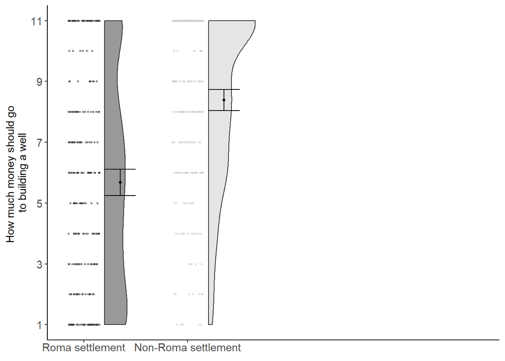

```r
descriptives = psych::describeBy(x = s1_1$well, group = s1_1$group)
group = c("Roma settlement","Non-Roma settlement")
means = c(descriptives$'Roma settlement'$mean, descriptives$'Non-Roma settlement'$mean)
se = c(descriptives$'Roma settlement'$se, descriptives$'Non-Roma settlement'$se)
plotdat=data.frame(group, means, se)

#fig <- image_graph(width = 1400, height = 650, res = 192)

(s1_1_main <- ggplot(data = s1_1, aes(y = well, x = group, fill = group)) + geom_flat_violin(data = s1_1, position = position_nudge(x = .2, y = 0), alpha = .5) + geom_point(data = s1_1, aes(y = well, color = group), position = position_jitter(width = .15,height = 0), size = .5, alpha = 0.5) + geom_point(data = plotdat, aes(x = group, y = means), position = position_nudge(x = 0.35), size = 1,inherit.aes = FALSE ) + geom_errorbar(inherit.aes=FALSE, data = plotdat, aes(x = group, ymax= means+(1.96*se), ymin=means+(-1.96*se), y=means), position = position_nudge(x = 0.35), width = 0.3) + expand_limits(x = 5) + guides(fill = FALSE) + guides(color = FALSE) + scale_color_grey() + scale_fill_grey() +
    #scale_color_brewer(palette = "Accent") +
    #scale_fill_brewer(palette = "Accent") +
    theme_bw() + raincloud_theme + labs(y = "How much money should go \nto building a well") + scale_x_discrete(expand = c(0.15,0.2))+ scale_y_continuous(breaks=c(1,3,5,7,9,11)))
```

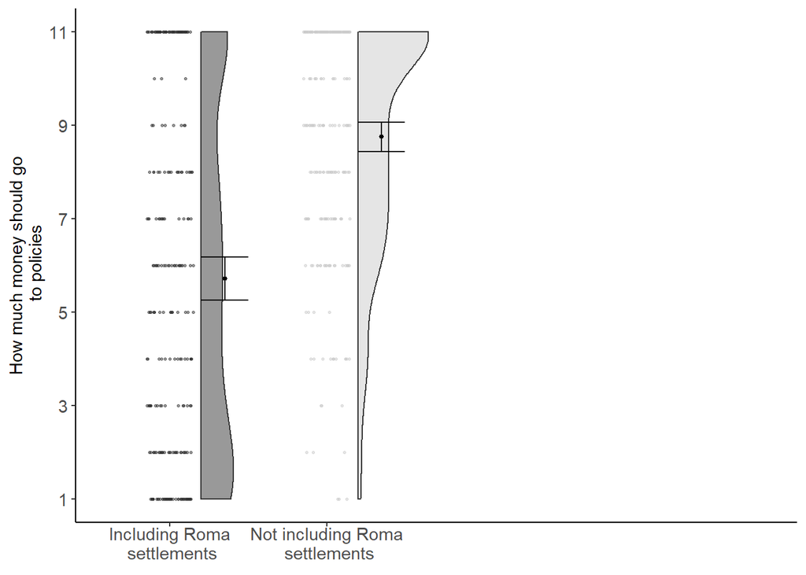

```r
# dev.off()
# out <- image_crop(fig, "750x750+0")
# print(out)

descriptives = psych::describeBy(x = s1_2$policies, group = s1_2$group)
group = c("including Roma","not including Roma")
means = c(descriptives$'including Roma'$mean, descriptives$'not including Roma'$mean)
se = c(descriptives$'including Roma'$se, descriptives$'not including Roma'$se)
plotdat=data.frame(group, means, se)

#fig <- image_graph(width = 1400, height = 650, res = 192)

(s1_2_main <- ggplot(data = s1_2, aes(y = policies, x = group, fill = group)) + geom_flat_violin(data = s1_2, position = position_nudge(x = .2, y = 0), alpha = .5) + geom_point(data = s1_2, aes(y = policies, color = group), position = position_jitter(width = .15,height = 0), size = .5, alpha = 0.5) + geom_point(data = plotdat, aes(x = group, y = means), position = position_nudge(x = 0.35), size = 1,inherit.aes = FALSE ) + geom_errorbar(inherit.aes=FALSE, data = plotdat, aes(x = group, ymax= means+(1.96*se), ymin=means+(-1.96*se), y=means), position = position_nudge(x = 0.35), width = 0.3) + expand_limits(x = 5) + guides(fill = FALSE) + guides(color = FALSE) + scale_color_grey() + scale_fill_grey() + theme_bw() + raincloud_theme + labs(y = "How much money should go\n to policies") + scale_x_discrete(expand = c(0.15,0.2))+  scale_x_discrete(labels = c('Including Roma\n settlements','Not including Roma\n settlements')) + scale_y_continuous(breaks=c(1,3,5,7,9,11)) )
```

```r
# dev.off()
# out <- image_crop(fig, "750x750+0")
# print(out)
```

## Main analysis

**Study 1 - opinion about the well**

The Welch Two Sample t-test testing the difference of s1_1$well by s1_1$group (mean in group Roma settlement = 5.68, mean in group Non-Roma settlement = 8.38) suggests that the effect is negative, statistically significant, and large (difference = -2.71, 95% CI [-3.26, -2.15], t(477.54) = -9.55, p < .001; Cohen’s d = -0.85, 95% CI [-1.03, -0.67])

```
 INDEPENDENT SAMPLES T-TEST

 Independent Samples T-Test
 ¦¦¦¦¦¦¦¦¦¦¦¦¦¦¦¦¦¦¦¦¦¦¦¦¦¦¦¦¦¦¦¦¦¦¦¦¦¦¦¦¦¦¦¦¦¦¦¦¦¦¦¦¦¦¦¦¦¦¦¦¦¦¦¦¦¦¦¦¦¦¦¦¦¦¦¦¦¦¦¦¦¦¦¦¦¦¦¦¦¦¦¦¦¦¦¦¦¦¦¦¦¦¦¦¦¦¦¦¦¦¦¦¦¦¦¦¦¦¦¦¦¦¦¦¦¦¦¦¦¦¦¦¦¦¦¦
                             Statistic    df     p         Mean difference    SE difference                                 Effect Size
 ¦¦¦¦¦¦¦¦¦¦¦¦¦¦¦¦¦¦¦¦¦¦¦¦¦¦¦¦¦¦¦¦¦¦¦¦¦¦¦¦¦¦¦¦¦¦¦¦¦¦¦¦¦¦¦¦¦¦¦¦¦¦¦¦¦¦¦¦¦¦¦¦¦¦¦¦¦¦¦¦¦¦¦¦¦¦¦¦¦¦¦¦¦¦¦¦¦¦¦¦¦¦¦¦¦¦¦¦¦¦¦¦¦¦¦¦¦¦¦¦¦¦¦¦¦¦¦¦¦¦¦¦¦¦¦¦
   well    Student's t           -9.55    501    < .001              -2.71            0.284    Cohen's d                         -0.852
           Welch's t             -9.55    478    < .001              -2.71            0.284    Cohen's d                         -0.851
           Mann-Whitney U        17785           < .001              -3.00                     Rank biserial correlation          0.438
 ¦¦¦¦¦¦¦¦¦¦¦¦¦¦¦¦¦¦¦¦¦¦¦¦¦¦¦¦¦¦¦¦¦¦¦¦¦¦¦¦¦¦¦¦¦¦¦¦¦¦¦¦¦¦¦¦¦¦¦¦¦¦¦¦¦¦¦¦¦¦¦¦¦¦¦¦¦¦¦¦¦¦¦¦¦¦¦¦¦¦¦¦¦¦¦¦¦¦¦¦¦¦¦¦¦¦¦¦¦¦¦¦¦¦¦¦¦¦¦¦¦¦¦¦¦¦¦¦¦¦¦¦¦¦¦¦
```

```
                     Estimate Std. Error Lower 95% Upper 95% P-value
```

(Intercept) 5.677 0.201 5.283 6.072 <0.001 groupNon-Roma settlement 2.708 0.284 2.151 3.265 <0.001 R Squared 0.154  
Adj.R Squared 0.1523

```r
s11.ancova <- aov(well ~ group + SEX + AGECAT + EDU + SIZE + REG + PINCOME, data=s1_1)
s11.ancova <-car::Anova(s11.ancova, type="III")
s11eta <- eta_squared(s11.ancova)

knitr::kable(s11.ancova, caption = " ")%>%
  kable_styling(full_width = F)
```

|  | Sum Sq | Df | F value | Pr(>F) |
| --- | --- | --- | --- | --- |
| (Intercept) | 457.385 | 1 | 45.583 | 0.000 |
| group | 823.564 | 1 | 82.076 | 0.000 |
| SEX | 0.266 | 1 | 0.027 | 0.871 |
| AGECAT | 58.149 | 5 | 1.159 | 0.328 |
| EDU | 50.972 | 3 | 1.693 | 0.168 |
| SIZE | 16.196 | 4 | 0.404 | 0.806 |
| REG | 96.929 | 7 | 1.380 | 0.212 |
| PINCOME | 80.602 | 8 | 1.004 | 0.432 |
| Residuals | 4746.180 | 473 | NA | NA |

```r
knitr::kable(s11eta, caption = " ")%>%
  kable_styling(full_width = F)
```

|  | x |
| --- | --- |
| (Intercept) | 0.072 |
| group | 0.130 |
| SEX | 0.000 |
| AGECAT | 0.009 |
| EDU | 0.008 |
| SIZE | 0.003 |
| REG | 0.015 |
| PINCOME | 0.013 |

```r
s1lm_well_cov <- lm(well ~ group + SEX + AGECAT + EDU + SIZE + REG + PINCOME, data = s1_1)
#report::report(s1lm_well_cov)
s11covtab <- report(s1lm_well_cov)
```

```
##                           Estimate Std. Error Lower 95% Upper 95% P-value
## (Intercept)                    6.3      0.933     4.466     8.133  <0.001
## groupNon-Roma settlement     2.631       0.29     2.061     3.202  <0.001
## SEXFemale                    -0.05      0.309    -0.658     0.557   0.871
## AGECAT25-34                  0.248      0.568    -0.869     1.365   0.663
## AGECAT35-44                  0.909      0.583    -0.237     2.055    0.12
## AGECAT45-54                   0.66      0.589    -0.498     1.818   0.263
## AGECAT55-64                  1.101      0.593    -0.063     2.266   0.064
## AGECAT65+                    0.927      0.654    -0.357     2.211   0.157
## EDUSecondary (no diploma)   -0.856      0.556    -1.949     0.237   0.125
## EDUSecondary (complete)     -0.218      0.555    -1.309     0.872   0.694
## EDUUniversity               -0.077      0.672    -1.399     1.244   0.908
## SIZE1k-4 999                 0.433       0.49     -0.53     1.396   0.378
## SIZE5k-19 999                0.333      0.567    -0.782     1.448   0.558
## SIZE20k - 99 999             0.524      0.489    -0.437     1.486   0.284
## SIZE100k+                    0.014      0.704    -1.369     1.397   0.984
## REGTrnavsky                 -1.495      0.716    -2.901    -0.088   0.037
## REGTrenciansky              -0.344      0.723    -1.765     1.078   0.635
## REGNitriansky               -1.238      0.712    -2.637     0.161   0.083
## REGZilinsky                 -0.439      0.704    -1.822     0.945   0.534
## REGBanskobystricky          -1.228      0.716    -2.636      0.18   0.087
## REGPresovsky                -1.125      0.711    -2.521     0.272   0.114
## REGKosicky                  -1.031      0.602    -2.214     0.151   0.087
## PINCOME2                    -0.575      0.422    -1.404     0.253   0.173
## PINCOME3                    -0.474      0.447    -1.352     0.403   0.289
## PINCOME4                    -0.304      0.566    -1.416     0.809   0.592
## PINCOME5                     0.739      0.749    -0.732      2.21   0.324
## PINCOME6                    -0.181      1.009    -2.164     1.801   0.857
## PINCOME7                     0.813      0.974      -1.1     2.726   0.404
## PINCOME8                     0.245      0.831    -1.389     1.878   0.769
## PINCOME9                    -1.062      0.756    -2.547     0.423    0.16
## R Squared                   0.2072
## Adj.R Squared               0.1586
```

```r
s11covtab<- as.data.frame(s11covtab[["output"]])
#write.csv(s11covtab,"s11covtab.csv")
```

**Study 1 - opinions about policies**

The Welch Two Sample t-test testing the difference of s1_2$policies by s1_2$group (mean in group including Roma = 5.72, mean in group not including Roma = 8.75) suggests that the effect is negative, statistically significant, and large (difference = -3.03, 95% CI [-3.59, -2.47], t(441.87) = -10.60, p < .001; Cohen’s d = -0.95, 95% CI [-1.13, -0.76])

```
 INDEPENDENT SAMPLES T-TEST

 Independent Samples T-Test
 ¦¦¦¦¦¦¦¦¦¦¦¦¦¦¦¦¦¦¦¦¦¦¦¦¦¦¦¦¦¦¦¦¦¦¦¦¦¦¦¦¦¦¦¦¦¦¦¦¦¦¦¦¦¦¦¦¦¦¦¦¦¦¦¦¦¦¦¦¦¦¦¦¦¦¦¦¦¦¦¦¦¦¦¦¦¦¦¦¦¦¦¦¦¦¦¦¦¦¦¦¦¦¦¦¦¦¦¦¦¦¦¦¦¦¦¦¦¦¦¦¦¦¦¦¦¦¦¦¦¦¦¦¦¦¦¦¦¦¦¦
                                 Statistic    df     p         Mean difference    SE difference                                 Effect Size
 ¦¦¦¦¦¦¦¦¦¦¦¦¦¦¦¦¦¦¦¦¦¦¦¦¦¦¦¦¦¦¦¦¦¦¦¦¦¦¦¦¦¦¦¦¦¦¦¦¦¦¦¦¦¦¦¦¦¦¦¦¦¦¦¦¦¦¦¦¦¦¦¦¦¦¦¦¦¦¦¦¦¦¦¦¦¦¦¦¦¦¦¦¦¦¦¦¦¦¦¦¦¦¦¦¦¦¦¦¦¦¦¦¦¦¦¦¦¦¦¦¦¦¦¦¦¦¦¦¦¦¦¦¦¦¦¦¦¦¦¦
   policies    Student's t           -10.5    497    < .001              -3.03            0.287    Cohen's d                         -0.944
               Welch's t             -10.6    442    < .001              -3.03            0.286    Cohen's d                         -0.947
               Mann-Whitney U        17099           < .001              -3.00                     Rank biserial correlation          0.451
 ¦¦¦¦¦¦¦¦¦¦¦¦¦¦¦¦¦¦¦¦¦¦¦¦¦¦¦¦¦¦¦¦¦¦¦¦¦¦¦¦¦¦¦¦¦¦¦¦¦¦¦¦¦¦¦¦¦¦¦¦¦¦¦¦¦¦¦¦¦¦¦¦¦¦¦¦¦¦¦¦¦¦¦¦¦¦¦¦¦¦¦¦¦¦¦¦¦¦¦¦¦¦¦¦¦¦¦¦¦¦¦¦¦¦¦¦¦¦¦¦¦¦¦¦¦¦¦¦¦¦¦¦¦¦¦¦¦¦¦¦
```

We fitted a linear model (estimated using OLS) to predict policies with group (formula: policies ~ group). The model explains a statistically significant and moderate proportion of variance (R2 = 0.18, F(1, 497) = 111.22, p < .001, adj. R2 = 0.18). The model’s intercept, corresponding to group = including Roma, is at 5.72 (95% CI [5.33, 6.12], t(497) = 28.38, p < .001). Within this model:

- The effect of group [not including Roma] is statistically significant and positive (beta = 3.03, 95% CI [2.46, 3.59], t(497) = 10.55, p < .001; Std. beta = 0.85, 95% CI [0.70, 1.01])

Standardized parameters were obtained by fitting the model on a standardized version of the dataset. 95% Confidence Intervals (CIs) and p-values were computed using the Wald approximation. Estimate Std. Error Lower 95% Upper 95% P-value (Intercept) 5.723 0.202 5.327 6.119 <0.001 groupnot including Roma 3.029 0.287 2.464 3.593 <0.001 R Squared 0.1829  
Adj.R Squared 0.1812

```r
s12.ancova <- aov(policies ~ group + SEX + AGECAT + EDU + SIZE + REG + PINCOME, data=s1_2)
s12.ancova <-car::Anova(s12.ancova, type="III")
s12eta <- eta_squared(s12.ancova)

knitr::kable(s12.ancova, caption = " ")%>%
  kable_styling(full_width = F)
```

|  | Sum Sq | Df | F value | Pr(>F) |
| --- | --- | --- | --- | --- |
| (Intercept) | 315.7 | 1 | 32.653 | 0.000 |
| group | 1152.2 | 1 | 119.155 | 0.000 |
| SEX | 81.2 | 1 | 8.393 | 0.004 |
| AGECAT | 113.2 | 5 | 2.341 | 0.041 |
| EDU | 93.4 | 3 | 3.218 | 0.023 |
| SIZE | 44.7 | 4 | 1.156 | 0.329 |
| REG | 108.9 | 7 | 1.609 | 0.131 |
| PINCOME | 59.8 | 8 | 0.773 | 0.627 |
| Residuals | 4535.0 | 469 | NA | NA |

```r
knitr::kable(s12eta, caption = " ")%>%
  kable_styling(full_width = F)
```

|  | x |
| --- | --- |
| (Intercept) | 0.049 |
| group | 0.177 |
| SEX | 0.012 |
| AGECAT | 0.017 |
| EDU | 0.014 |
| SIZE | 0.007 |
| REG | 0.017 |
| PINCOME | 0.009 |

```r
s1lm_policies_cov <- lm(policies ~ group+ SEX + AGECAT + EDU + SIZE + REG + PINCOME, data = s1_2)
#report::report(s1lm_policies_cov)
s12covtab <- report(s1lm_policies_cov)
```

```
##                           Estimate Std. Error Lower 95% Upper 95% P-value
## (Intercept)                  5.308      0.929     3.483     7.134  <0.001
## groupnot including Roma      3.114      0.285     2.554     3.675  <0.001
## SEXFemale                   -0.909      0.314    -1.525    -0.292   0.004
## AGECAT25-34                  0.894      0.538    -0.163     1.951   0.097
## AGECAT35-44                  1.071      0.573    -0.056     2.198   0.063
## AGECAT45-54                   1.38      0.569     0.262     2.497   0.016
## AGECAT55-64                  1.908      0.588     0.752     3.064   0.001
## AGECAT65+                    1.375      0.626     0.144     2.606   0.029
## EDUSecondary (no diploma)   -0.866      0.573    -1.992     0.259   0.131
## EDUSecondary (complete)     -0.729      0.555     -1.82     0.361   0.189
## EDUUniversity                0.298      0.623    -0.927     1.523   0.633
## SIZE1k-4 999                -0.251      0.477    -1.188     0.686   0.599
## SIZE5k-19 999               -0.497      0.529    -1.537     0.542   0.348
## SIZE20k - 99 999            -0.483      0.491    -1.447     0.481   0.326
## SIZE100k+                    0.735      0.665    -0.572     2.042    0.27
## REGTrnavsky                  0.622      0.697    -0.748     1.991   0.373
## REGTrenciansky               0.466      0.708    -0.925     1.858    0.51
## REGNitriansky               -0.135      0.693    -1.497     1.228   0.846
## REGZilinsky                  0.669      0.712     -0.73     2.069   0.348
## REGBanskobystricky            1.45      0.726     0.024     2.876   0.046
## REGPresovsky                 1.236       0.68      -0.1     2.573    0.07
## REGKosicky                   0.748      0.573    -0.377     1.873   0.192
## PINCOME2                     -0.48      0.425    -1.314     0.355   0.259
## PINCOME3                     0.129      0.466    -0.787     1.046   0.781
## PINCOME4                     -0.65      0.569    -1.768     0.467   0.254
## PINCOME5                    -0.743      0.775    -2.266      0.78   0.338
## PINCOME6                    -0.919      1.101    -3.083     1.245   0.405
## PINCOME7                     1.073      1.145    -1.178     3.323   0.349
## PINCOME8                    -0.072      0.687    -1.421     1.278   0.917
## PINCOME9                    -0.364      0.712    -1.764     1.036   0.609
## R Squared                   0.2752
## Adj.R Squared               0.2304
```

```r
s12covtab<- as.data.frame(s12covtab[["output"]])
#write.csv(s12covtab,"s12covtab.csv")
```

Interaction with income

```r
incomes11 <- dplyr::filter(s1_1, income != 'NA')
lms11 <- lm(well ~ group * income, data = incomes11)
report(lms11)
```

```
##                                             Estimate Std. Error Lower 95%
## (Intercept)                                    5.888       0.32     5.258
## groupNon-Roma settlement                       2.657      0.439     1.795
## incomebelow median                            -0.323      0.424    -1.155
## groupNon-Roma settlement:incomebelow median    0.101      0.594    -1.066
## R Squared                                     0.1584
## Adj.R Squared                                 0.1529
##                                             Upper 95% P-value
## (Intercept)                                     6.517  <0.001
## groupNon-Roma settlement                        3.519  <0.001
## incomebelow median                              0.509   0.446
## groupNon-Roma settlement:incomebelow median     1.267   0.866
## R Squared
## Adj.R Squared
```

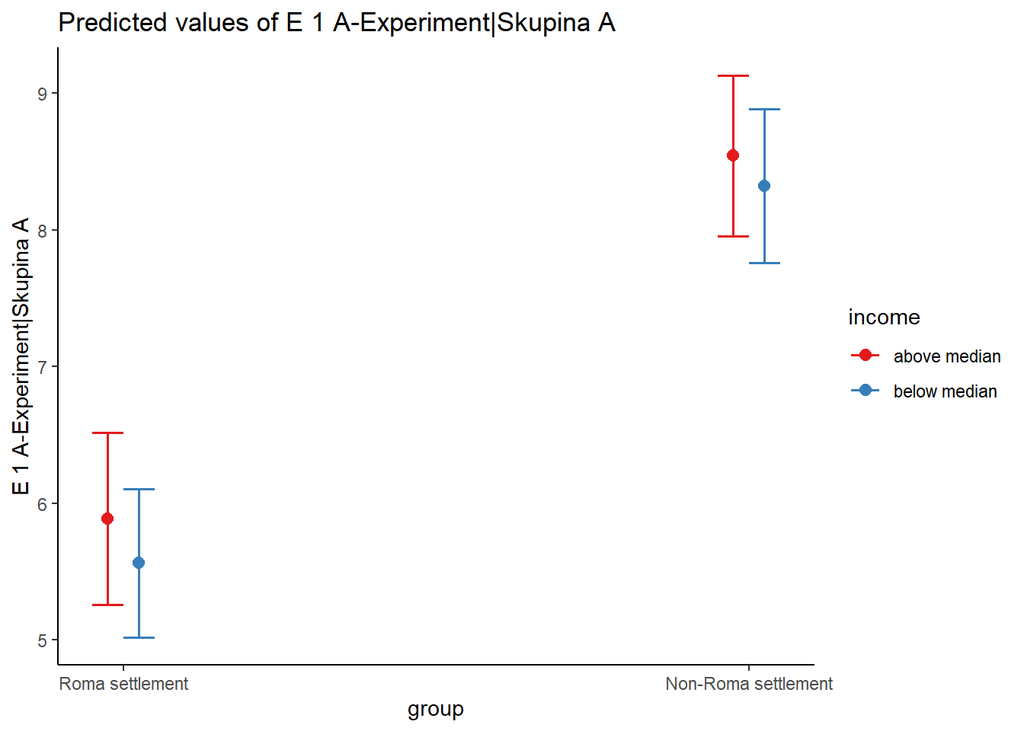

```r
plot_model(lms11, type = "pred", terms = c("group", "income")) + theme_classic()
```

```r
#summ <- summ(lms11 )
#summ <- as.data.frame(summ[["coeftable"]])


incomes12 <- dplyr::filter(s1_2, income != 'NA')
lms12 <- lm(policies ~ group * income, data = incomes12)
report(lms12)
```

```
##                                            Estimate Std. Error Lower 95%
## (Intercept)                                   6.115      0.316     5.494
## groupnot including Roma                       3.057       0.46     2.153
## incomebelow median                           -0.652      0.429    -1.496
## groupnot including Roma:incomebelow median   -0.032      0.617    -1.245
## R Squared                                    0.1883
## Adj.R Squared                                0.1828
##                                            Upper 95% P-value
## (Intercept)                                    6.737  <0.001
## groupnot including Roma                        3.961  <0.001
## incomebelow median                             0.192    0.13
## groupnot including Roma:incomebelow median      1.18   0.958
## R Squared
## Adj.R Squared
```

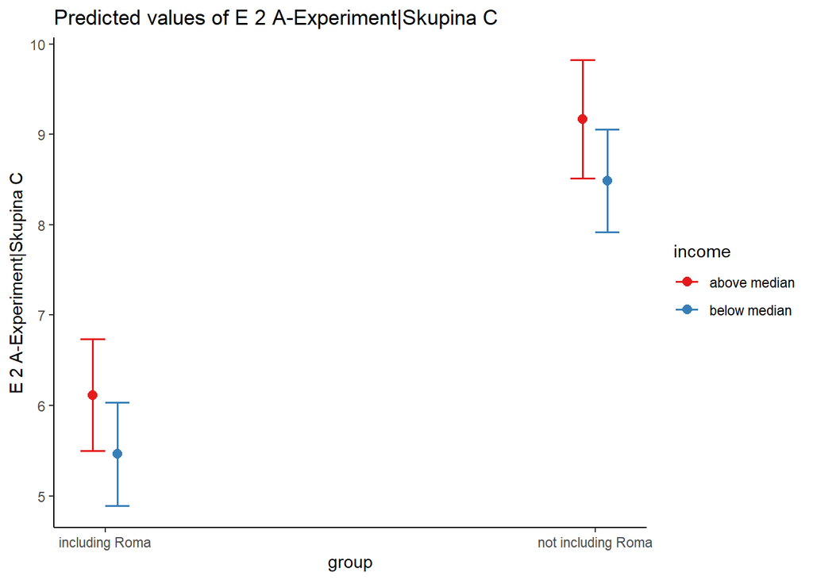

```r
plot_model(lms12, type = "pred", terms = c("group", "income")) + theme_classic()
```

```r
#summ <- summ(lms12 )
#summ <- as.data.frame(summ[["coeftable"]])
```

# Study 2

## Data

### Data load

```r
# s2 <- s2 %>%
#    dplyr::select(-StartDate,-EndDate,-Status,-IPAddress,-Progress,-Duration__in_seconds_,-Finished,-RecordedDate,-ResponseId,-RecipientLastName,-RecipientFirstName,-RecipientEmail,-ExternalReference,-DistributionChannel,-UserLanguage)
#
# export(s2, "Study2.sav")

s2 <- import("data/Study2.sav")
```

### Data prep

```r
s2$home= factor(s2$home, levels = c(1, 2,3,4), labels = c("home-answered","away-notanswered","home-return", "away-return"))
s2$consent= factor(s2$consent, levels = c(1, 2), labels = c("yes","no"))
s2$etnic_ascr= factor(s2$etnic_ascr, levels = c(1, 2), labels = c("slovak","roma"))
s2$etnicita= factor(s2$etnicita, levels = c(1, 2,3), labels = c("slovak","roma","other"))
s2$age <- as.numeric(s2$age)
s2 <- lessR::recode(age, new_vars="roky_", old=9:72, new=1996:1933, data=s2)
s2$years <- 2019 - s2$roky
s2$gender <- factor(s2$gender, levels = c(1, 2), labels = c("Male","Female"))
s2_consent <- dplyr::filter(s2, consent=="yes")
s2_consent <- dplyr::filter(s2_consent, etnic_ascr != "NA")
s2_consent <- dplyr::filter(s2_consent, eurofondy_iv<5 & skolka_iv<5 & skolka_agree<5 & skolka_vote<5 & skolka_norms < 5 & control < 5 & suma < 5 & praca < 5 & potreba<5 & pila <5 )
```

## Descriptives

### Main outcomes

```r
s2_consent %>% dplyr::group_by(etnic_ascr) %>% dplyr::summarise(N = length(control), Min=min(control,na.rm= TRUE),Q1 = quantile(control,probs = .25,na.rm = TRUE),Median = median(control, na.rm = TRUE),Q3 = quantile(control,probs = .75,na.rm = TRUE),Max = max(control,na.rm = TRUE),Mean = mean(control, na.rm = TRUE),SD = sd(control, na.rm = TRUE), Skew = skewness(control, na.rm = TRUE), Kurtosis = kurtosis(control, na.rm = TRUE)) -> s2_control

knitr::kable(s2_control, caption = "Study 2 - control")%>%
  kable_styling(full_width = F)
```

Study 2 - control

| etnic_ascr | N | Min | Q1 | Median | Q3 | Max | Mean | SD | Skew | Kurtosis |
| --- | --- | --- | --- | --- | --- | --- | --- | --- | --- | --- |
| slovak | 52 | 1 | 1 | 2 | 3 | 4 | 2.25 | 1.153 | 0.276 | -1.38 |
| roma | 61 | 1 | 4 | 4 | 4 | 4 | 3.67 | 0.724 | -2.344 | 5.40 |

```r
s2_consent %>% dplyr::group_by(etnic_ascr) %>% dplyr::summarise(N = length(suma), Min=min(suma,na.rm= TRUE),Q1 = quantile(suma,probs = .25,na.rm = TRUE),Median = median(suma, na.rm = TRUE),Q3 = quantile(suma,probs = .75,na.rm = TRUE),Max = max(suma,na.rm = TRUE),Mean = mean(suma, na.rm = TRUE),SD = sd(suma, na.rm = TRUE), Skew = skewness(suma, na.rm = TRUE), Kurtosis = kurtosis(suma, na.rm = TRUE)) -> s2_equal

knitr::kable(s2_equal, caption = "Study 2 - equality")%>%
  kable_styling(full_width = F)
```

Study 2 - equality

| etnic_ascr | N | Min | Q1 | Median | Q3 | Max | Mean | SD | Skew | Kurtosis |
| --- | --- | --- | --- | --- | --- | --- | --- | --- | --- | --- |
| slovak | 52 | 1 | 2 | 3 | 4 | 4 | 2.88 | 1.114 | -0.544 | -1.046 |
| roma | 61 | 1 | 3 | 3 | 4 | 4 | 3.21 | 0.859 | -1.059 | 0.803 |

```r
s2_consent %>% dplyr::group_by(etnic_ascr) %>% dplyr::summarise(N = length(praca), Min=min(praca,na.rm= TRUE),Q1 = quantile(praca,probs = .25,na.rm = TRUE),Median = median(praca, na.rm = TRUE),Q3 = quantile(praca,probs = .75,na.rm = TRUE),Max = max(praca,na.rm = TRUE),Mean = mean(praca, na.rm = TRUE),SD = sd(praca, na.rm = TRUE), Skew = skewness(praca, na.rm = TRUE), Kurtosis = kurtosis(praca, na.rm = TRUE)) -> s2_prop

knitr::kable(s2_prop, caption = "Study 2 - proportionality")%>%
  kable_styling(full_width = F)
```

Study 2 - proportionality

| etnic_ascr | N | Min | Q1 | Median | Q3 | Max | Mean | SD | Skew | Kurtosis |
| --- | --- | --- | --- | --- | --- | --- | --- | --- | --- | --- |
| slovak | 52 | 1 | 3 | 3 | 4 | 4 | 3.04 | 1.07 | -0.862 | -0.422 |
| roma | 61 | 1 | 2 | 3 | 4 | 4 | 2.88 | 1.13 | -0.548 | -1.083 |

```r
s2_consent %>% dplyr::group_by(etnic_ascr) %>% dplyr::summarise(N = length(potreba), Min=min(potreba,na.rm= TRUE),Q1 = quantile(potreba,probs = .25,na.rm = TRUE),Median = median(potreba, na.rm = TRUE),Q3 = quantile(potreba,probs = .75,na.rm = TRUE),Max = max(potreba,na.rm = TRUE),Mean = mean(potreba, na.rm = TRUE),SD = sd(potreba, na.rm = TRUE), Skew = skewness(potreba, na.rm = TRUE), Kurtosis = kurtosis(potreba, na.rm = TRUE)) -> s2_need

knitr::kable(s2_need, caption = "Study 2 - need")%>%
  kable_styling(full_width = F)
```

Study 2 - need

| etnic_ascr | N | Min | Q1 | Median | Q3 | Max | Mean | SD | Skew | Kurtosis |
| --- | --- | --- | --- | --- | --- | --- | --- | --- | --- | --- |
| slovak | 52 | 1 | 1 | 2.5 | 3 | 4 | 2.42 | 1.13 | 0.027 | -1.38 |
| roma | 61 | 1 | 3 | 4.0 | 4 | 4 | 3.66 | 0.68 | -2.339 | 6.31 |

```r
s2_consent <- mutate(s2_consent, ID = row_number())

s2_mains <- melt(s2_consent,
        # ID variables - all the variables to keep but not split apart on
    id.vars=c("etnic_ascr", "ID","eurofondy_iv","skolka_iv" ),
        # The source columns
    measure.vars=c("control", "suma", "praca","potreba","pila"),
        # Name of the destination column that will identify the original
        # column that the measurement came from
    variable.name="condition",
    value.name="measurement"
)

s2_mains <- filter(s2_mains, condition!="pila")

s2_dvs <- s2_mains %>%
  group_by(etnic_ascr,condition)%>%
  dplyr::select(-ID:-skolka_iv) %>%
  get_summary_stats(type = c("mean_sd"))%>%
  dplyr::select(-variable)%>%
  dplyr::mutate(condition = dplyr::recode(condition,
    "control" = "Control",
    "suma" = "Equality",
    "praca" = "Reciprocity",
    "potreba" = "Need"))%>%
  dplyr::mutate(sd = round(sd,2))


dvstt <- s2_mains %>%
#  pivot_longer(contains("att_"))%>%
    group_by(etnic_ascr)%>%
    t_test(measurement~condition, detailed = T)
```

### Sample characteristics

```r
s2_consent_gender <- s2_consent %>% group_by(gender) %>%
dplyr::summarise(n = n()) %>%
  mutate(freq = n / sum(n))
s2_consent_gender$freq <- round(s2_consent_gender$freq, 3)

s2_consent_gender%>%
kable(caption = "Gender")%>%
  kable_styling(full_width = F)
```

Gender

| gender | n | freq |
| --- | --- | --- |
| Male | 43 | 0.381 |
| Female | 70 | 0.619 |

```r
s2_consent_age <- s2_consent %>% dplyr::summarise(Min=min(years,na.rm= TRUE),Q1 = quantile(years,probs = .25,na.rm = TRUE),Median = median(years, na.rm = TRUE),Q3 = quantile(years,probs = .75,na.rm = TRUE),Max = max(years,na.rm = TRUE),Mean = round(mean(years, na.rm = TRUE),3),SD = round(sd(years, na.rm = TRUE),2),n = n(),Missing = sum(is.na(years)))

s2_consent_age %>%
  kable(caption = "Age") %>%
  kable_styling(full_width = F)
```

Age

| Min | Q1 | Median | Q3 | Max | Mean | SD | n | Missing |
| --- | --- | --- | --- | --- | --- | --- | --- | --- |
| 23 | 35 | 47 | 63 | 85 | 49.3 | 16.1 | 113 | 0 |

```r
s2_consent_etnic <- s2_consent %>% group_by(etnic_ascr) %>%
dplyr::summarise(n = n()) %>%
  mutate(freq = n / sum(n))
s2_consent_etnic$freq <- round(s2_consent_etnic$freq, 3)

s2_consent_etnic%>%
kable(caption = "Ascribed ethnicity")%>%
  kable_styling(full_width = F)
```

Ascribed ethnicity

| etnic_ascr | n | freq |
| --- | --- | --- |
| slovak | 52 | 0.46 |
| roma | 61 | 0.54 |

```r
s2_consent_etnic_self <- s2_consent %>% group_by(etnicita) %>%
dplyr::summarise(n = n()) %>%
  mutate(freq = n / sum(n))
s2_consent_etnic_self$freq <- round(s2_consent_etnic_self$freq, 3)

s2_consent_etnic_self%>%
kable(caption = "Self-reported ethnicity")%>%
  kable_styling(full_width = F)
```

Self-reported ethnicity

| etnicita | n | freq |
| --- | --- | --- |
| slovak | 92 | 0.814 |
| roma | 18 | 0.159 |
| other | 3 | 0.027 |

## Plots

### Main outcomes

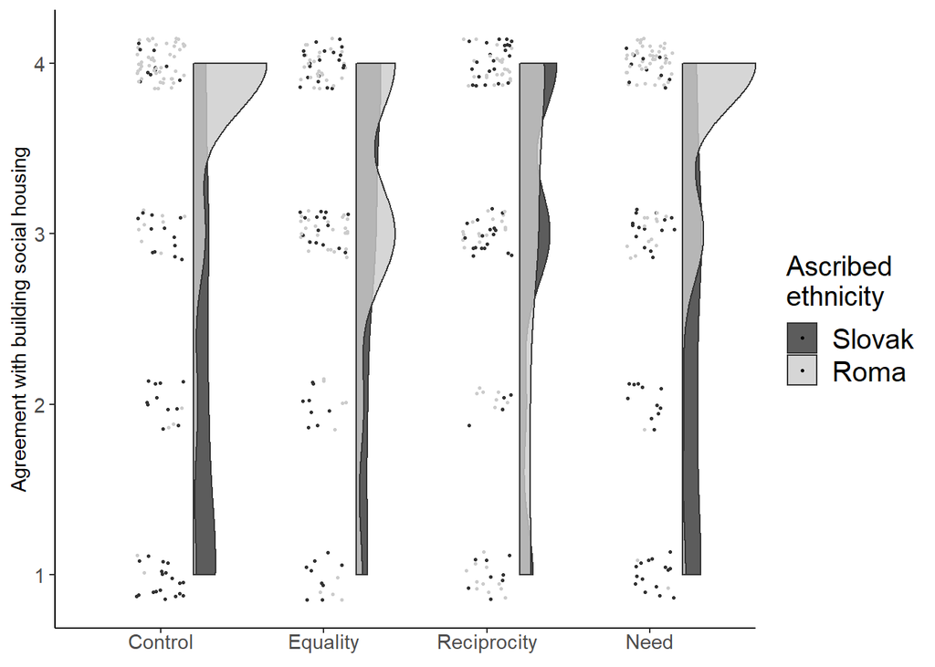

```r
#fig <- image_graph(width = 1400, height = 650, res = 192)

ggplot(data = s2_mains, aes(y = measurement, x = condition, fill = etnic_ascr)) + geom_flat_violin(data = s2_mains, position = position_nudge(x = .2, y = 0), alpha = .8) + geom_point(data = s2_mains, aes(y = measurement, color = etnic_ascr), position = position_jitter(width = .15,height = .15), size = .5, alpha = 1.2) +
    scale_color_grey() +
    scale_fill_grey(labels=c("Slovak","Roma")) +
    theme_bw() + raincloud_theme + labs(y = "Agreement with building social housing") + scale_x_discrete(expand = c(0.15,0.2),labels=c("Control","Equality","Reciprocity","Need"))+ labs(fill='Ascribed \nethnicity') + guides(color = FALSE)
```

```r
#dev.off()
#out <- image_crop(fig, "1380x750+0")
#print(out)
```

## Main analysis

```r
s2_mains$condition <- dplyr::recode(s2_mains$condition, suma = "equal", praca = "reciprocity", potreba="need", control = "control")
s2_mains$measurement <- as.factor(s2_mains$measurement)

model <- clmm(measurement ~ condition * etnic_ascr + (1|ID),data = s2_mains, threshold = "equidistant", Hess = T)
summary(model)
```

```
## Cumulative Link Mixed Model fitted with the Laplace approximation
##
## formula: measurement ~ condition * etnic_ascr + (1 | ID)
## data:    s2_mains
##
##  link  threshold   nobs logLik  AIC     niter     max.grad cond.H
##  logit equidistant 452  -494.69 1009.38 637(2517) 2.48e-05 2.3e+02
##
## Random effects:
##  Groups Name        Variance Std.Dev.
##  ID     (Intercept) 2.22     1.49
## Number of groups:  ID 113
##
## Coefficients:
##                                     Estimate Std. Error z value       Pr(>|z|)
## conditionequal                         1.442      0.397    3.63        0.00028
## conditionreciprocity                   1.723      0.401    4.30 0.000017340183
## conditionneed                          0.360      0.380    0.95        0.34372
## etnic_ascrroma                         3.780      0.554    6.82 0.000000000009
## conditionequal:etnic_ascrroma         -3.095      0.594   -5.21 0.000000187408
## conditionreciprocity:etnic_ascrroma   -4.102      0.616   -6.65 0.000000000028
## conditionneed:etnic_ascrroma          -0.582      0.599   -0.97        0.33080
##
## conditionequal                      ***
## conditionreciprocity                ***
## conditionneed
## etnic_ascrroma                      ***
## conditionequal:etnic_ascrroma       ***
## conditionreciprocity:etnic_ascrroma ***
## conditionneed:etnic_ascrroma
## ---
## Signif. codes:  0 '***' 0.001 '**' 0.01 '*' 0.05 '.' 0.1 ' ' 1
##
## Threshold coefficients:
##             Estimate Std. Error z value
## threshold.1   -0.994      0.356   -2.79
## spacing        1.556      0.116   13.42
```

```r
Anova.clmm(model, type = "II")
```

```
## Analysis of Deviance Table (Type II tests)
##
## Response: measurement
##                      LR Chisq Df         Pr(>Chisq)
## condition                 1.3  3               0.74
## etnic_ascr               24.5  1 0.0000007581231238 ***
## condition:etnic_ascr     68.4  3 0.0000000000000095 ***
## ---
## Signif. codes:  0 '***' 0.001 '**' 0.01 '*' 0.05 '.' 0.1 ' ' 1
```

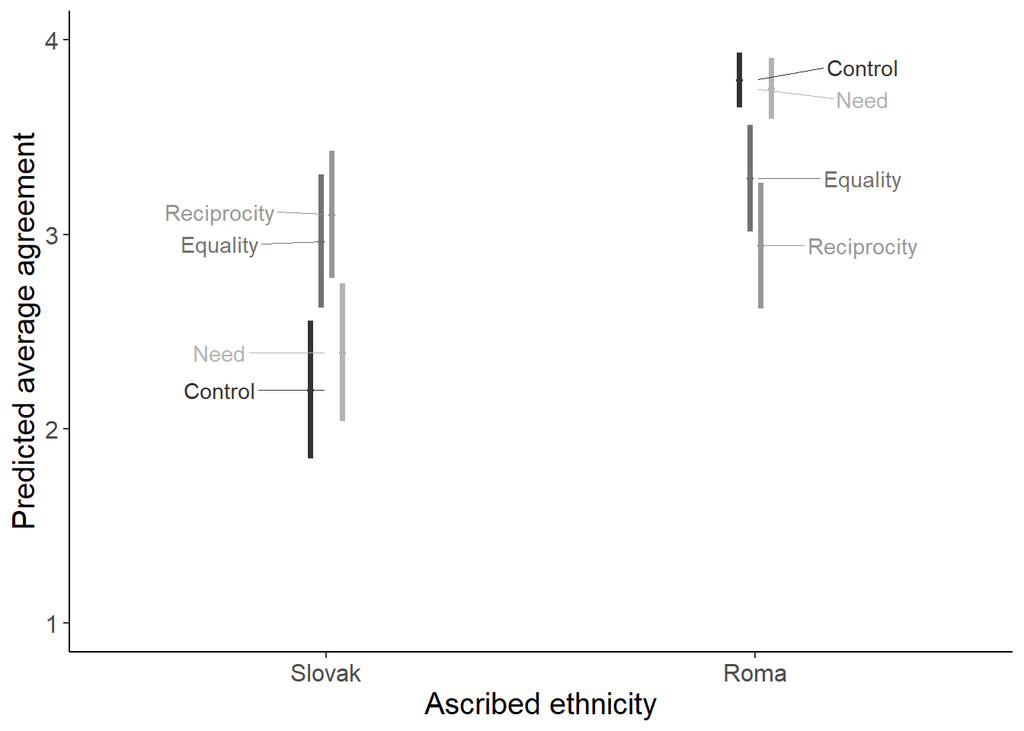

```r
emmip <- emmip(model, condition ~ etnic_ascr, CIs = T, engine = "ggplot",style = "factor", plotit = F, mode= "mean.class")

names(emmip)[8] <- "Condition"
emmip$Condition <- dplyr::recode(emmip$Condition , 'control' = "Control", "reciprocity" = 'Reciprocity', "need" = 'Need', "equal" = 'Equality')
emmip$xvar <- dplyr::recode(emmip$xvar , 'slovak' = "Slovak", "roma" = 'Roma')

(emmplot <- ggplot(data = emmip, aes(y= yvar, x = xvar, group = Condition)) + geom_point(size=1.3, position=position_dodge(width=0.1), aes(color = Condition)) + #geom_line(size=1.3,position=position_dodge(width=0.1),aes(linetype=Condition, color=Condition))+
    geom_linerange(size=1.3,aes(x = xvar,
                     ymin = LCL,
                     ymax = UCL, color = Condition),
                 show.legend = FALSE,position=position_dodge(width=0.1))+
    scale_color_grey(start = 0.2, end = 0.7) +
    scale_fill_grey(start = 0.2, end = 0.7)+theme_classic()  + labs(y = "Predicted average agreement", x = 'Ascribed ethnicity') +
  geom_text_repel(aes(label = Condition, colour = Condition),
    data          = subset(emmip, xvar == "Slovak"),
    nudge_x       = -0.25,
    segment.size  = 0.2,
    direction     = "y") +
  geom_text_repel(aes(label = Condition, colour = Condition),
    data          = subset(emmip, xvar == "Roma"),
    nudge_x       = 0.25,
    segment.size  = 0.2,
    direction     = "y") + theme(legend.position="none")+
  scale_linetype_manual(values=c("twodash", "dotted","longdash", "solid" ))+
    theme(text = element_text(size=15)) + ylim(1,4) )
```

```r
#ggsave("plot.png", width = 6, height = 5)

emmip%>%
kable(caption = "Predicted average agreement")%>%
  kable_styling(full_width = F)
```

Predicted average agreement

| condition | etnic_ascr | yvar | SE | df | LCL | UCL | Condition | xvar |
| --- | --- | --- | --- | --- | --- | --- | --- | --- |
| control | slovak | 2.20 | 0.181 | Inf | 1.85 | 2.56 | Control | Slovak |
| equal | slovak | 2.96 | 0.175 | Inf | 2.62 | 3.31 | Equality | Slovak |
| reciprocity | slovak | 3.10 | 0.167 | Inf | 2.78 | 3.43 | Reciprocity | Slovak |
| need | slovak | 2.39 | 0.181 | Inf | 2.04 | 2.75 | Need | Slovak |
| control | roma | 3.79 | 0.072 | Inf | 3.65 | 3.94 | Control | Roma |
| equal | roma | 3.29 | 0.140 | Inf | 3.01 | 3.56 | Equality | Roma |
| reciprocity | roma | 2.94 | 0.165 | Inf | 2.62 | 3.27 | Reciprocity | Roma |
| need | roma | 3.75 | 0.080 | Inf | 3.59 | 3.91 | Need | Roma |

# Study 3

## Data

### Data load

```r
s3 <- import("data/Study3.sav")
```

### Data prep

```r
s3$group= factor(s3$SKUPINA, levels = c(1, 2,3,4), labels = c("Control","Equality", "Proportionality", "Need"))
s3$SEX <- factor(s3$SEX, levels = c(1, 2), labels = c("Male","Female"))
s3$AGECAT= factor(s3$AGECAT, levels = c(1,2,3,4,5,6), labels = c("18-24","25-34","35-44", "45-54","55-64","65+"))
s3$EDU= factor(s3$EDU, levels = c(1, 2,3,4), labels = c("Primary","Secondary (no diploma)","Secondary (complete)", "University"))
s3$SIZE= factor(s3$SIZE, levels = c(1, 2,3,4,5), labels = c("less than 1k","1k-4 999","5k-19 999", "20k - 99 999","100k+"))
s3$REG= factor(s3$REG, levels = c(1, 2,3,4,5,6,7,8), labels = c("Bratislavsky","Trnavsky","Trenciansky", "Nitriansky","Zilinsky","Banskobystricky","Presovsky","Kosicky"))


s3$income <- car::recode(s3$PINCOME,"'1'='below median';'2'='below median';'8'='NA';'9'='NA'; else = 'above median'")
```

## Descriptives

### Main outcomes

```r
s3 %>% dplyr::group_by(group) %>% dplyr::summarise(N = length(E3), Min=min(E3,na.rm= TRUE),Q1 = quantile(E3,probs = .25,na.rm = TRUE),Median = median(E3, na.rm = TRUE),Q3 = quantile(E3,probs = .75,na.rm = TRUE),Max = max(E3,na.rm = TRUE),Mean = mean(E3, na.rm = TRUE),SD = sd(E3, na.rm = TRUE), Skew = skewness(E3, na.rm = TRUE), Kurtosis = kurtosis(E3, na.rm = TRUE)) -> s3_personal

knitr::kable(s3_personal, caption = "Study 3 - personal agreement")%>%
  kable_styling(full_width = F)
```

Study 3 - personal agreement

| group | N | Min | Q1 | Median | Q3 | Max | Mean | SD | Skew | Kurtosis |
| --- | --- | --- | --- | --- | --- | --- | --- | --- | --- | --- |
| Control | 252 | 1 | 1 | 3 | 3 | 4 | 2.50 | 1.08 | -0.121 | -1.28 |
| Equality | 249 | 1 | 2 | 3 | 3 | 4 | 2.63 | 1.04 | -0.328 | -1.06 |
| Proportionality | 254 | 1 | 2 | 3 | 4 | 4 | 2.83 | 1.06 | -0.561 | -0.89 |
| Need | 254 | 1 | 1 | 3 | 3 | 4 | 2.40 | 1.07 | -0.054 | -1.29 |

```r
s3 %>% dplyr::group_by(group) %>% dplyr::summarise(N = length(E4), Min=min(E4,na.rm= TRUE),Q1 = quantile(E4,probs = .25,na.rm = TRUE),Median = median(E4, na.rm = TRUE),Q3 = quantile(E4,probs = .75,na.rm = TRUE),Max = max(E4,na.rm = TRUE),Mean = mean(E4, na.rm = TRUE),SD = sd(E4, na.rm = TRUE), Skew = skewness(E4, na.rm = TRUE), Kurtosis = kurtosis(E4, na.rm = TRUE)) -> s3_majority

knitr::kable(s3_majority, caption = "Study 3 - agreement of majority")%>%
  kable_styling(full_width = F)
```

Study 3 - agreement of majority

| group | N | Min | Q1 | Median | Q3 | Max | Mean | SD | Skew | Kurtosis |
| --- | --- | --- | --- | --- | --- | --- | --- | --- | --- | --- |
| Control | 252 | 1 | 1 | 2 | 3 | 4 | 1.82 | 0.875 | 0.524 | -1.048 |
| Equality | 249 | 1 | 1 | 2 | 3 | 4 | 2.01 | 0.946 | 0.413 | -0.979 |
| Proportionality | 254 | 1 | 1 | 2 | 3 | 4 | 2.21 | 0.967 | 0.143 | -1.093 |
| Need | 254 | 1 | 1 | 2 | 2 | 4 | 1.81 | 0.816 | 0.482 | -0.960 |

### Sample characteristics

```r
s3_gender <- s3 %>% group_by(SEX) %>%
dplyr::summarise(n = n()) %>%
  mutate(freq = n / sum(n))
s3_gender$freq <- round(s3_gender$freq, 3)

s3_gender%>%
kable(caption = "Gender")%>%
  kable_styling(full_width = F)
```

Gender

| SEX | n | freq |
| --- | --- | --- |
| Male | 486 | 0.482 |
| Female | 523 | 0.518 |

```r
s3_age <- s3 %>% dplyr::summarise(Min=min(AGE,na.rm= TRUE),Q1 = quantile(AGE,probs = .25,na.rm = TRUE),Median = median(AGE, na.rm = TRUE),Q3 = quantile(AGE,probs = .75,na.rm = TRUE),Max = max(AGE,na.rm = TRUE),Mean = round(mean(AGE, na.rm = TRUE),3),SD = round(sd(AGE, na.rm = TRUE),2),n = n(),Missing = sum(is.na(AGE)))

s3_age %>%
  kable(caption = "Age") %>%
  kable_styling(full_width = F)
```

Age

| Min | Q1 | Median | Q3 | Max | Mean | SD | n | Missing |
| --- | --- | --- | --- | --- | --- | --- | --- | --- |
| 18 | 31 | 44 | 59 | 80 | 44.7 | 16.1 | 1009 | 0 |

```r
s3_agecat  <- s3 %>% group_by(AGECAT) %>%
dplyr::summarise(n = n()) %>%
  mutate(freq = n / sum(n))
s3_agecat$freq <- round(s3_agecat$freq, 3)

s3_agecat%>%
kable(caption = "Age categories")%>%
  kable_styling(full_width = F)
```

Age categories

| AGECAT | n | freq |
| --- | --- | --- |
| 18-24 | 130 | 0.129 |
| 25-34 | 198 | 0.196 |
| 35-44 | 179 | 0.177 |
| 45-54 | 177 | 0.175 |
| 55-64 | 165 | 0.164 |
| 65+ | 160 | 0.159 |

```r
s3_educat <- s3 %>% group_by(EDU) %>%
dplyr::summarise(n = n()) %>%
  mutate(freq = n / sum(n))
s3_educat$freq <- round(s3_educat$freq, 3)

s3_educat%>%
kable(caption = "Education categories")%>%
  kable_styling(full_width = F)
```

Education categories

| EDU | n | freq |
| --- | --- | --- |
| Primary | 94 | 0.093 |
| Secondary (no diploma) | 348 | 0.345 |
| Secondary (complete) | 378 | 0.375 |
| University | 189 | 0.187 |

```r
s3_reg <- s3 %>% group_by(REG) %>%
dplyr::summarise(n = n()) %>%
  mutate(freq = n / sum(n))
s3_reg$freq <- round(s3_reg$freq, 3)

s3_reg%>%
kable(caption = "Region")%>%
  kable_styling(full_width = F)
```

Region

| REG | n | freq |
| --- | --- | --- |
| Bratislavsky | 111 | 0.110 |
| Trnavsky | 106 | 0.105 |
| Trenciansky | 117 | 0.116 |
| Nitriansky | 135 | 0.134 |
| Zilinsky | 127 | 0.126 |
| Banskobystricky | 115 | 0.114 |
| Presovsky | 147 | 0.146 |
| Kosicky | 151 | 0.150 |

```r
s3_municip <- s3 %>% group_by(SIZE) %>%
dplyr::summarise(n = n()) %>%
  mutate(freq = n / sum(n))
s3_municip$freq <- round(s3_municip$freq, 3)

s3_municip%>%
kable(caption = "Municipality size")%>%
  kable_styling(full_width = F)
```

Municipality size

| SIZE | n | freq |
| --- | --- | --- |
| less than 1k | 146 | 0.145 |
| 1k-4 999 | 293 | 0.290 |
| 5k-19 999 | 166 | 0.165 |
| 20k - 99 999 | 274 | 0.272 |
| 100k+ | 130 | 0.129 |

### Randomization checks

```r
s3_check <- dplyr::select(s3, SEX:PINCOME, -AGECAT, group)
s3_check <- mutate_all(s3_check, function(x) as.numeric(x))

s3_check <- col_oneway_welch(s3_check[,1:5], s3_check$group)

s3_check %>%
  kable(caption = "Randomization checks overall") %>%
  kable_styling(full_width = F)
```

Randomization checks overall

|  | obs.tot | obs.groups | df.between | df.within | statistic | pvalue |
| --- | --- | --- | --- | --- | --- | --- |
| SEX | 1009 | 4 | 3 | 558 | 4.725 | 0.003 |
| EDU | 1009 | 4 | 3 | 558 | 0.064 | 0.979 |
| REG | 1009 | 4 | 3 | 558 | 0.341 | 0.796 |
| SIZE | 1009 | 4 | 3 | 558 | 1.524 | 0.207 |
| PINCOME | 1009 | 4 | 3 | 558 | 0.191 | 0.903 |

```r
table(s3$SEX, s3$group)
```

```
##
##          Control Equality Proportionality Need
##   Male       110      108             121  147
##   Female     142      141             133  107
```

## Plots

### Main outcomes

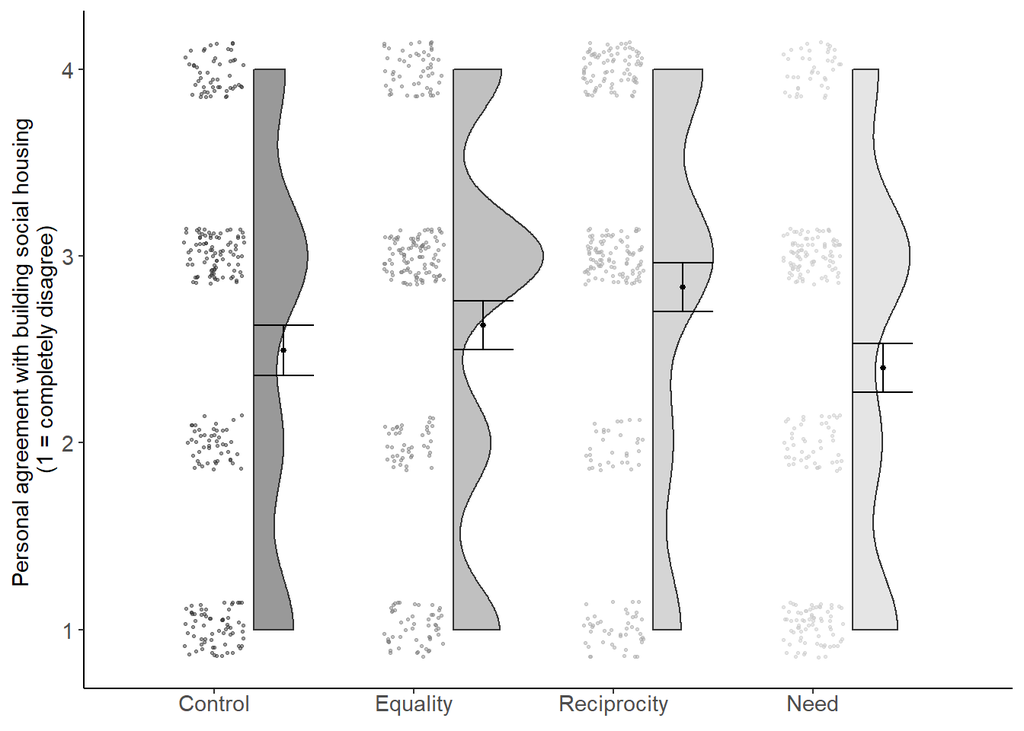

```r
descriptives = psych::describeBy(x = s3$E3, group = s3$group)
group = c("Control","Equality", "Proportionality", "Need")
means = c(descriptives$'Control'$mean, descriptives$'Equality'$mean,descriptives$'Proportionality'$mean, descriptives$'Need'$mean)
se = c(descriptives$'Control'$se, descriptives$'Equality'$se,descriptives$'Proportionality'$se, descriptives$'Need'$se)
plotdat=data.frame(group, means, se)

(s3_personal <- ggplot(data = s3, aes(y = E3, x = group, fill = group)) + geom_flat_violin(data = s3, position = position_nudge(x = .2, y = 0), alpha = .5) + geom_point(data = s3, aes(y = E3, color = group), position = position_jitter(width = .15,height = .15), size = .5, alpha = 0.5) + geom_point(data = plotdat, aes(x = group, y = means), position = position_nudge(x = 0.35), size = 1,inherit.aes = FALSE ) + geom_errorbar(inherit.aes=FALSE, data = plotdat, aes(x = group, ymax= means+(1.96*se), ymin=means+(-1.96*se), y=means), position = position_nudge(x = 0.35), width = 0.3) + expand_limits(x = 5) + guides(fill = FALSE) + guides(color = FALSE) + scale_color_grey() + scale_fill_grey() +
    #scale_color_brewer(palette = "Accent") +
    #scale_fill_brewer(palette = "Accent") +
    theme_bw() + raincloud_theme + labs(y = "Personal agreement with building social housing \n(1 = completely disagree)") + scale_x_discrete(expand = c(0.15,0.2),labels=c("Control","Equality", 'Proportionality'="Reciprocity", "Need")))
```

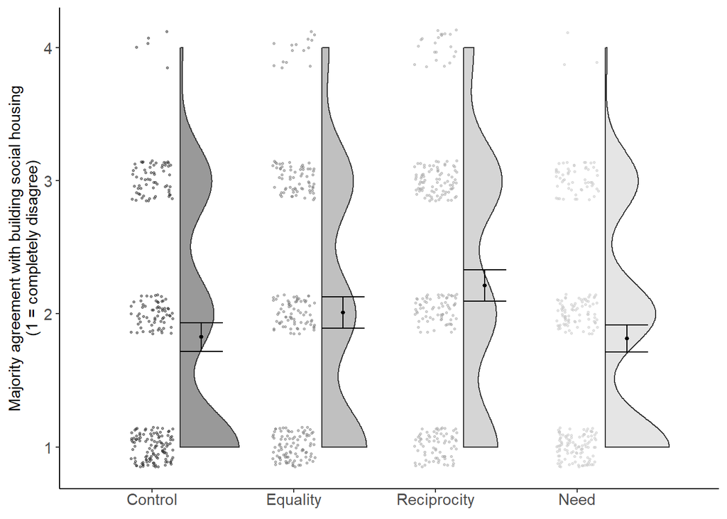

```r
#ggsave("plot.png", width = 6, height = 4)

descriptives = psych::describeBy(x = s3$E4, group = s3$group)
group = c("Control","Equality", "Proportionality", "Need")
means = c(descriptives$'Control'$mean, descriptives$'Equality'$mean,descriptives$'Proportionality'$mean, descriptives$'Need'$mean)
se = c(descriptives$'Control'$se, descriptives$'Equality'$se,descriptives$'Proportionality'$se, descriptives$'Need'$se)
plotdat=data.frame(group, means, se)

(s3_majority <- ggplot(data = s3, aes(y = E4, x = group, fill = group)) + geom_flat_violin(data = s3, position = position_nudge(x = .2, y = 0), alpha = .5) + geom_point(data = s3, aes(y = E4, color = group), position = position_jitter(width = .15,height = .15), size = .5, alpha = 0.5) + geom_point(data = plotdat, aes(x = group, y = means), position = position_nudge(x = 0.35), size = 1,inherit.aes = FALSE ) + geom_errorbar(inherit.aes=FALSE, data = plotdat, aes(x = group, ymax= means+(1.96*se), ymin=means+(-1.96*se), y=means), position = position_nudge(x = 0.35), width = 0.3) + expand_limits(x = 5) + guides(fill = FALSE) + guides(color = FALSE) + scale_color_grey() + scale_fill_grey() +
    #scale_color_brewer(palette = "Accent") +
    #scale_fill_brewer(palette = "Accent") +
    theme_bw() + raincloud_theme + labs(y = " Majority agreement with building social housing \n(1 = completely disagree)") + scale_x_discrete(expand = c(0.15,0.2),labels=c("Control","Equality", 'Proportionality'="Reciprocity", "Need")))
```

```r
#ggsave("plot.png", width = 6, height = 4)
```

## Main analysis - separate ordinal regression

```r
s3$E1 <- as.ordered(s3$E1)
s3$E2 <- as.ordered(s3$E2)
s3$E3 <- as.ordered(s3$E3)
s3$E4 <- as.ordered(s3$E4)


s3personal  <- polr(E3 ~ group, data = s3, Hess=TRUE)
summary(s3personal)
```

```
## Call:
## polr(formula = E3 ~ group, data = s3, Hess = TRUE)
##
## Coefficients:
##                       Value Std. Error t value
## groupEquality         0.220      0.161   1.366
## groupProportionality  0.604      0.163   3.696
## groupNeed            -0.159      0.160  -0.989
##
## Intercepts:
##     Value  Std. Error t value
## 1|2 -1.050  0.123     -8.570
## 2|3 -0.250  0.118     -2.124
## 3|4  1.430  0.127     11.264
##
## Residual Deviance: 2682.53
## AIC: 2694.53
```

```r
ctable <- coef(summary(s3personal))
p <- pnorm(abs(ctable[, "t value"]), lower.tail = FALSE) * 2
(ctable <- cbind(ctable, "p value" = p))
```

```
##                       Value Std. Error t value
## groupEquality         0.220      0.161   1.366
## groupProportionality  0.604      0.163   3.696
## groupNeed            -0.159      0.160  -0.989
## 1|2                  -1.050      0.123  -8.570
## 2|3                  -0.250      0.118  -2.124
## 3|4                   1.430      0.127  11.264
##                                                p value
## groupEquality        0.1719829489387951215739747112821
## groupProportionality 0.0002189898061911927154826046360
## groupNeed            0.3225011740560665973731602207408
## 1|2                  0.0000000000000000103253973248736
## 2|3                  0.0336704266773589222516704921873
## 3|4                  0.0000000000000000000000000000199
```

```r
ci <- confint(s3personal)
exp(cbind(OR = coef(s3personal), ci))
```

```
##                         OR 2.5 % 97.5 %
## groupEquality        1.246 0.909   1.71
## groupProportionality 1.829 1.329   2.52
## groupNeed            0.853 0.623   1.17
```

```r
s3majority  <- polr(E4 ~ group, data = s3, Hess=TRUE)
summary(s3majority)
```

```
## Call:
## polr(formula = E4 ~ group, data = s3, Hess = TRUE)
##
## Coefficients:
##                       Value Std. Error t value
## groupEquality        0.3538      0.166   2.133
## groupProportionality 0.7638      0.166   4.609
## groupNeed            0.0166      0.164   0.102
##
## Intercepts:
##     Value  Std. Error t value
## 1|2 -0.169  0.120     -1.413
## 2|3  1.078  0.125      8.654
## 3|4  3.389  0.187     18.117
##
## Residual Deviance: 2430.82
## AIC: 2442.82
```

```r
ctable <- coef(summary(s3majority))
p <- pnorm(abs(ctable[, "t value"]), lower.tail = FALSE) * 2
(ctable <- cbind(ctable, "p value" = p))
```

```
##                        Value Std. Error t value
## groupEquality         0.3538      0.166   2.133
## groupProportionality  0.7638      0.166   4.609
## groupNeed             0.0166      0.164   0.102
## 1|2                  -0.1694      0.120  -1.413
## 2|3                   1.0780      0.125   8.654
## 3|4                   3.3889      0.187  18.117
##                                                                                            p value
## groupEquality        0.032933660357249705530335859293700195848941802978515625000000000000000000000
## groupProportionality 0.000004038777410760396074668882038238848508626688271760940551757812500000000
## groupNeed            0.919138560434128670806330774212256073951721191406250000000000000000000000000
## 1|2                  0.157693310258532781720219873022870160639286041259765625000000000000000000000
## 2|3                  0.000000000000000004966205382876902558152154565362934590666554868221282958984
## 3|4                  0.000000000000000000000000000000000000000000000000000000000000000000000000232
```

```r
ci <- confint(s3majority)
exp(cbind(OR = coef(s3majority), ci))
```

```
##                        OR 2.5 % 97.5 %
## groupEquality        1.42 1.030   1.97
## groupProportionality 2.15 1.553   2.97
## groupNeed            1.02 0.738   1.40
```

```r
# Re-level to have Proportionality as baseline

s3$group <- relevel(s3$group, ref = "Proportionality")
s3personal  <- polr(E3 ~ group, data = s3, Hess=TRUE)
summary(s3personal)
```

```
## Call:
## polr(formula = E3 ~ group, data = s3, Hess = TRUE)
##
## Coefficients:
##                Value Std. Error t value
## groupControl  -0.604      0.163   -3.70
## groupEquality -0.384      0.163   -2.36
## groupNeed     -0.763      0.163   -4.68
##
## Intercepts:
##     Value   Std. Error t value
## 1|2  -1.654   0.130    -12.722
## 2|3  -0.853   0.122     -6.982
## 3|4   0.826   0.122      6.786
##
## Residual Deviance: 2682.53
## AIC: 2694.53
```

```r
ctable <- coef(summary(s3personal))
p <- pnorm(abs(ctable[, "t value"]), lower.tail = FALSE) * 2
(ctable <- cbind(ctable, "p value" = p))
```

```
##                Value Std. Error t value
## groupControl  -0.604      0.163   -3.70
## groupEquality -0.384      0.163   -2.36
## groupNeed     -0.763      0.163   -4.68
## 1|2           -1.654      0.130  -12.72
## 2|3           -0.853      0.122   -6.98
## 3|4            0.826      0.122    6.79
##                                                 p value
## groupControl  0.000219128357637360827048916833703628981
## groupEquality 0.018233252015677360591272559986464329995
## groupNeed     0.000002858246491254943567363044909512837
## 1|2           0.000000000000000000000000000000000000446
## 2|3           0.000000000002907573419456666752487550287
## 3|4           0.000000000011554251685090759454001621553
```

```r
ci <- confint(s3personal)
exp(cbind(OR = coef(s3personal), ci))
```

```
##                  OR 2.5 % 97.5 %
## groupControl  0.547 0.397  0.753
## groupEquality 0.681 0.495  0.937
## groupNeed     0.466 0.339  0.641
```

```r
s3majority  <- polr(E4 ~ group, data = s3, Hess=TRUE)
summary(s3majority)
```

```
## Call:
## polr(formula = E4 ~ group, data = s3, Hess = TRUE)
##
## Coefficients:
##                Value Std. Error t value
## groupControl  -0.764      0.166   -4.61
## groupEquality -0.410      0.165   -2.49
## groupNeed     -0.747      0.163   -4.58
##
## Intercepts:
##     Value  Std. Error t value
## 1|2 -0.933  0.122     -7.621
## 2|3  0.314  0.119      2.632
## 3|4  2.625  0.177     14.810
##
## Residual Deviance: 2430.82
## AIC: 2442.82
```

```r
ctable <- coef(summary(s3majority))
p <- pnorm(abs(ctable[, "t value"]), lower.tail = FALSE) * 2
(ctable <- cbind(ctable, "p value" = p))
```

```
##                Value Std. Error t value
## groupControl  -0.764      0.166   -4.61
## groupEquality -0.410      0.165   -2.49
## groupNeed     -0.747      0.163   -4.58
## 1|2           -0.933      0.122   -7.62
## 2|3            0.314      0.119    2.63
## 3|4            2.625      0.177   14.81
##                                                             p value
## groupControl  0.000004037502680358655213644497594671634033147711307
## groupEquality 0.012819927074820316667547182021280605113133788108826
## groupNeed     0.000004592728132773489383225418158929187484318390489
## 1|2           0.000000000000025082063135431974505804714192791493588
## 2|3           0.008485871348432458965982405629802087787538766860962
## 3|4           0.000000000000000000000000000000000000000000000000126
```

```r
ci <- confint(s3majority)
exp(cbind(OR = coef(s3majority), ci))
```

```
##                  OR 2.5 % 97.5 %
## groupControl  0.466 0.336  0.644
## groupEquality 0.664 0.480  0.916
## groupNeed     0.474 0.344  0.651
```

## Main analysis - ordinal regression, interactions with income

```r
s3income <- dplyr::filter(s3, income != 'NA')

s3income$group <- relevel(s3income$group, ref = "Control")

s3income3  <- polr(E3 ~ group * income, data = s3income, Hess=TRUE)
summary(s3income3)
```

```
## Call:
## polr(formula = E3 ~ group * income, data = s3income, Hess = TRUE)
##
## Coefficients:
##                                           Value Std. Error t value
## groupProportionality                     0.4412      0.245   1.800
## groupEquality                            0.3404      0.236   1.441
## groupNeed                               -0.0868      0.239  -0.364
## incomebelow median                      -0.0990      0.240  -0.413
## groupProportionality:incomebelow median  0.2745      0.341   0.806
## groupEquality:incomebelow median        -0.3701      0.340  -1.090
## groupNeed:incomebelow median            -0.0757      0.337  -0.224
##
## Intercepts:
##     Value  Std. Error t value
## 1|2 -1.124  0.175     -6.432
## 2|3 -0.307  0.171     -1.794
## 3|4  1.395  0.178      7.851
##
## Residual Deviance: 2431.43
## AIC: 2451.43
```

```r
ctable <- coef(summary(s3income3))
p <- pnorm(abs(ctable[, "t value"]), lower.tail = FALSE) * 2
(ctable <- cbind(ctable, "p value" = p))
```

```
##                                           Value Std. Error t value
## groupProportionality                     0.4412      0.245   1.800
## groupEquality                            0.3404      0.236   1.441
## groupNeed                               -0.0868      0.239  -0.364
## incomebelow median                      -0.0990      0.240  -0.413
## groupProportionality:incomebelow median  0.2745      0.341   0.806
## groupEquality:incomebelow median        -0.3701      0.340  -1.090
## groupNeed:incomebelow median            -0.0757      0.337  -0.224
## 1|2                                     -1.1242      0.175  -6.432
## 2|3                                     -0.3066      0.171  -1.794
## 3|4                                      1.3955      0.178   7.851
##                                                     p value
## groupProportionality                    0.07191399889720881
## groupEquality                           0.14946827297049570
## groupNeed                               0.71595995935224654
## incomebelow median                      0.67967744794504859
## groupProportionality:incomebelow median 0.42052887583057746
## groupEquality:incomebelow median        0.27579521433616505
## groupNeed:incomebelow median            0.82245002985014604
## 1|2                                     0.00000000012584739
## 2|3                                     0.07286735687205270
## 3|4                                     0.00000000000000414
```

```r
ci <- confint(s3income3)
exp(cbind(OR = coef(s3income3), ci))
```

```
##                                            OR 2.5 % 97.5 %
## groupProportionality                    1.555 0.962   2.52
## groupEquality                           1.406 0.885   2.23
## groupNeed                               0.917 0.574   1.46
## incomebelow median                      0.906 0.566   1.45
## groupProportionality:incomebelow median 1.316 0.675   2.57
## groupEquality:incomebelow median        0.691 0.355   1.34
## groupNeed:incomebelow median            0.927 0.479   1.80
```

```r
s3income4  <- polr(E4 ~ group * income, data = s3income, Hess=TRUE)
summary(s3income4)
```

```
## Call:
## polr(formula = E4 ~ group * income, data = s3income, Hess = TRUE)
##
## Coefficients:
##                                          Value Std. Error t value
## groupProportionality                     0.872      0.249   3.501
## groupEquality                            0.621      0.242   2.564
## groupNeed                                0.221      0.239   0.925
## incomebelow median                       0.221      0.247   0.897
## groupProportionality:incomebelow median -0.260      0.347  -0.750
## groupEquality:incomebelow median        -0.666      0.349  -1.907
## groupNeed:incomebelow median            -0.449      0.343  -1.307
##
## Intercepts:
##     Value  Std. Error t value
## 1|2 -0.080  0.173     -0.464
## 2|3  1.144  0.177      6.469
## 3|4  3.426  0.227     15.062
##
## Residual Deviance: 2210.25
## AIC: 2230.25
```

```r
ctable <- coef(summary(s3income4))
p <- pnorm(abs(ctable[, "t value"]), lower.tail = FALSE) * 2
(ctable <- cbind(ctable, "p value" = p))
```

```
##                                          Value Std. Error t value
## groupProportionality                     0.872      0.249   3.501
## groupEquality                            0.621      0.242   2.564
## groupNeed                                0.221      0.239   0.925
## incomebelow median                       0.221      0.247   0.897
## groupProportionality:incomebelow median -0.260      0.347  -0.750
## groupEquality:incomebelow median        -0.666      0.349  -1.907
## groupNeed:incomebelow median            -0.449      0.343  -1.307
## 1|2                                     -0.080      0.173  -0.464
## 2|3                                      1.144      0.177   6.469
## 3|4                                      3.426      0.227  15.062
##                                                                                         p value
## groupProportionality                    0.00046392593379359292008606852064644954225514084100723
## groupEquality                           0.01033291459378540139146807064207678195089101791381836
## groupNeed                               0.35516868347149183060551536073035094887018203735351562
## incomebelow median                      0.36992470446731212652125009299197699874639511108398437
## groupProportionality:incomebelow median 0.45303545684809687354999141462030820548534393310546875
## groupEquality:incomebelow median        0.05657798606517257938852694110209995415061712265014648
## groupNeed:incomebelow median            0.19123004644452828992839954480587039142847061157226562
## 1|2                                     0.64293119709798152161539519511279650032520294189453125
## 2|3                                     0.00000000009854308616597394583289104552648041135398671
## 3|4                                     0.00000000000000000000000000000000000000000000000000286
```

```r
ci <- confint(s3income4)
exp(cbind(OR = coef(s3income4), ci))
```

```
##                                            OR 2.5 % 97.5 %
## groupProportionality                    2.392 1.470   3.91
## groupEquality                           1.861 1.159   3.00
## groupNeed                               1.247 0.781   1.99
## incomebelow median                      1.248 0.769   2.03
## groupProportionality:incomebelow median 0.771 0.391   1.52
## groupEquality:incomebelow median        0.514 0.259   1.02
## groupNeed:incomebelow median            0.638 0.325   1.25
```

Interaction with EU fund attitudes and perceived competitiveness

```r
s3$E1_coll <- car::recode(s3$E1,"'1'='2'")
s3$E2_coll <- car::recode(s3$E2,"'1'='2'")

s3$E1_coll <- as.ordered(s3$E1_coll)
s3$E2_coll <- as.ordered(s3$E2_coll)

s3_fit_all <- MANOVA.wide(cbind(E3, E4) ~ group * E1_coll * E2_coll, data = s3, iter = 1000, CPU = 1)

summary(s3_fit_all)
```

```
## Call:
## cbind(E3, E4) ~ group * E1_coll * E2_coll
##
## Descriptive:
##              group E1_coll E2_coll  n   E3   E4
## 1  Proportionality       2       2  9 2.78 1.78
## 2  Proportionality       2       3  6 3.17 2.83
## 3  Proportionality       2       4 26 1.85 1.54
## 4  Proportionality       3       2 18 3.22 2.17
## 5  Proportionality       3       3 42 3.14 2.57
## 6  Proportionality       3       4 57 2.42 2.04
## 7  Proportionality       4       2 19 3.53 2.32
## 8  Proportionality       4       3 27 3.41 2.41
## 9  Proportionality       4       4 50 2.82 2.34
## 10         Control       2       2 12 2.25 1.75
## 11         Control       2       3 10 3.10 2.00
## 12         Control       2       4 20 1.60 1.30
## 13         Control       3       2 15 2.73 2.27
## 14         Control       3       3 45 2.76 2.07
## 15         Control       3       4 52 2.00 1.60
## 16         Control       4       2 25 3.64 2.08
## 17         Control       4       3 31 2.84 1.84
## 18         Control       4       4 42 2.17 1.76
## 19        Equality       2       2 16 2.44 2.00
## 20        Equality       2       3 11 3.09 2.46
## 21        Equality       2       4 25 1.88 1.32
## 22        Equality       3       2 15 2.80 2.13
## 23        Equality       3       3 39 2.92 2.18
## 24        Equality       3       4 64 2.33 1.84
## 25        Equality       4       2 13 2.92 2.69
## 26        Equality       4       3 26 3.27 2.23
## 27        Equality       4       4 40 2.67 2.00
## 28            Need       2       2  5 2.60 2.00
## 29            Need       2       3  9 2.22 2.11
## 30            Need       2       4 29 1.76 1.48
## 31            Need       3       2 18 2.78 2.17
## 32            Need       3       3 44 2.52 1.89
## 33            Need       3       4 54 1.89 1.48
## 34            Need       4       2 18 3.44 2.39
## 35            Need       4       3 31 2.94 2.03
```

[output cut: 16 more lines]

```
## group:E1_coll                   6.67
## E2_coll                       200.37
## group:E2_coll                  20.64
## E1_coll:E2_coll                23.05
## group:E1_coll:E2_coll          18.69
##
## p-values resampling:
##                       paramBS (WTS) paramBS (MATS)
## group                 "<0.001"      "<0.001"
## E1_coll               "<0.001"      "<0.001"
## group:E1_coll         "0.81"        "0.863"
## E2_coll               "<0.001"      "<0.001"
## group:E2_coll         "0.051"       "0.105"
## E1_coll:E2_coll       "0.03"        "0.006"
## group:E1_coll:E2_coll "0.658"       "0.81"
```

```r
simCI(s3_fit_all, contrast = "pairwise", type = "Tukey", interaction = F, factor ="group")
```

```
##
##  #------ Call -----#
##
##  - Contrast:  Tukey
##  - Confidence level: 95 %
##
##  #------Multivariate post-hoc comparisons: p-values -----#
##
##                     contrast p.value
## 1  Control - Proportionality   0.018
## 2 Equality - Proportionality   0.355
## 3     Need - Proportionality   0.002
## 4         Equality - Control   0.563
## 5             Need - Control   0.977
## 6            Need - Equality   0.295
##
##  #-----------Confidence intervals for summary effects-------------#
##
##                            Estimate  Lower  Upper
## Control - Proportionality    -0.727 -1.359 -0.095
## Equality - Proportionality   -0.409 -1.046  0.228
## Need - Proportionality       -0.831 -1.451 -0.211
## Equality - Control            0.318 -0.311  0.947
## Need - Control               -0.104 -0.716  0.508
## Need - Equality              -0.422 -1.039  0.195
```